# Project 5: Vehicle Detection & Tracking

The goals / steps of this project are the following:

- Perform a Histogram of Oriented Gradients (HOG) feature extraction on a labeled training set of images and train a classifier Linear SVM classifier
- Optionally, you can also apply a color transform and append binned color features, as well as histograms of color, to your HOG feature vector.
- Note: for those first two steps don't forget to normalize your features and randomize a selection for training and testing.
- Implement a sliding-window technique and use your trained classifier to search for vehicles in images.
- Run your pipeline on a video stream (start with the test_video.mp4 and later implement on full project_video.mp4) and create a heat map of recurring detections frame by frame to reject outliers and follow detected vehicles.
- Estimate a bounding box for vehicles detected.

# Project Dependencies

```python
import numpy as np
import cv2
import glob
import time
import matplotlib.pyplot as plt
import matplotlib.image as mpimg
from mpl_toolkits.mplot3d import Axes3D
from skimage.feature import hog
from sklearn.preprocessing import StandardScaler
from sklearn.model_selection import train_test_split
from sklearn.model_selection import GridSearchCV
from scipy.ndimage.measurements import label
from sklearn import svm

from moviepy.editor import *
from IPython.display import HTML
```

## Load Test Images

```python
def load_test_images():
    images = []
    for path in glob.glob('test_images/*.jpg'):
        img = mpimg.imread(path)
        images.append(img)

    return images

test_images = load_test_images()
```

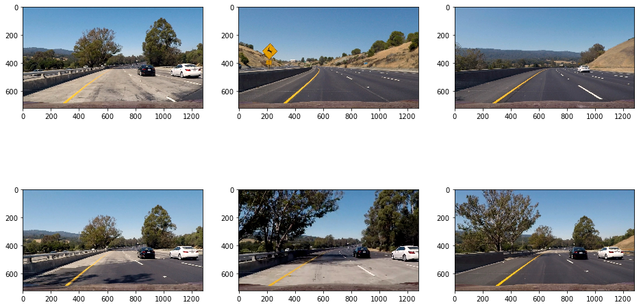

```python
def plot_grid(images):
    """Helper function to plot a list of images as a grid with 3 columns."""
    fig = plt.figure(figsize=(16,9))

    columns = 3
    rows = round(len(images)/columns)

    for index, img in enumerate(images):
        a = fig.add_subplot(rows,columns,index+1)
        plt.imshow(img)
    plt.show()

plot_grid(test_images)
```

# Explore Color Spaces

In this section I use various visualization techniques to determine what might the best methods for extracting features from each image.

```python
def convert_color(image, conv='RGB'):
    """Convenience function for converting between RGB and various color spaces."""

    img = np.copy(image)

    if conv == 'RGB2YCrCb':
        return cv2.cvtColor(img, cv2.COLOR_RGB2YCrCb)
    elif conv == 'RGB2HSV':
        return cv2.cvtColor(img, cv2.COLOR_RGB2HSV)
    elif conv == 'RGB2LUV':
        return cv2.cvtColor(img, cv2.COLOR_RGB2LUV)
    elif conv == 'RGB2HLS':
        return cv2.cvtColor(img, cv2.COLOR_RGB2HLS)
    elif conv == 'RGB2YUV':
        return cv2.cvtColor(img, cv2.COLOR_RGB2YUV)
    else:
        # Retain RGB image
        return img
```

```python
color_spaces = ['RGB', 'RGB2YCrCb', 'RGB2HSV', 'RGB2LUV', 'RGB2HLS', 'RGB2YUV']
```

### 3D Color Space Visualization

Visulizing color spaces in this way gives a clearer indication of how it might be possible to ditinguish various features in an image based on their distrubution.

```python
def plot3d(pixels, colors_rgb, axis_labels=list("RGB"), axis_limits=[(0, 255), (0, 255), (0, 255)]):
    """Plot pixels in 3D."""

    # Create figure and 3D axes
    fig = plt.figure(figsize=(4, 4))

    ax = Axes3D(fig)

    # Set axis limits
    ax.set_xlim(*axis_limits[0])
    ax.set_ylim(*axis_limits[1])
    ax.set_zlim(*axis_limits[2])

    # Set axis labels and sizes
    ax.tick_params(axis='both', which='major', labelsize=14, pad=8)
    ax.set_xlabel(axis_labels[0], fontsize=16, labelpad=16)
    ax.set_ylabel(axis_labels[1], fontsize=16, labelpad=16)
    ax.set_zlabel(axis_labels[2], fontsize=16, labelpad=16)

    # Plot pixel values with colors given in colors_rgb
    ax.scatter(
        pixels[:, :, 0].ravel(),
        pixels[:, :, 1].ravel(),
        pixels[:, :, 2].ravel(),
        c=colors_rgb.reshape((-1, 3)), edgecolors='none')

    return ax  # return Axes3D object for further manipulation


# Read a color image
img = mpimg.imread("test_images/test6.jpg")

# Select a small fraction of pixels to plot by subsampling it
scale = max(img.shape[0], img.shape[1], 64) / 64  # at most 64 rows and columns
img_small = cv2.resize(img, (np.int(img.shape[1] / scale), np.int(img.shape[0] / scale)), interpolation=cv2.INTER_NEAREST)

# Convert subsampled image to desired color space(s)
img_small_rgb = img_small / 255.  # scaled to [0, 1], only for plotting
```

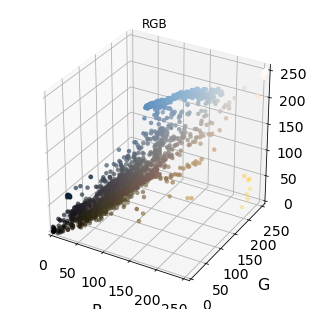

```python
# Plot and show
plot3d(img_small, img_small_rgb)
plt.title('RGB')
plt.show()
```

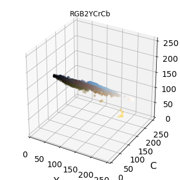

```python
plot3d(convert_color(img_small, color_spaces[1]), img_small_rgb, axis_labels=list("YCC"))
plt.title(color_spaces[1])
plt.show()
```

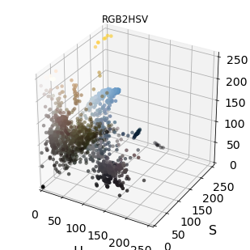

```python
plot3d(convert_color(img_small, color_spaces[2]), img_small_rgb, axis_labels=list("HSV"))
plt.title(color_spaces[2])
plt.show()
```

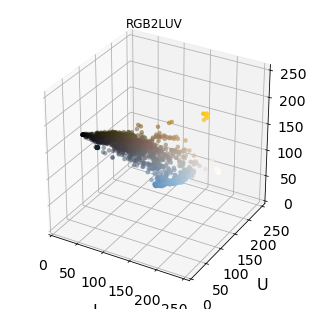

```python
plot3d(convert_color(img_small, color_spaces[3]), img_small_rgb, axis_labels=list("LUV"))
plt.title(color_spaces[3])
plt.show()
```

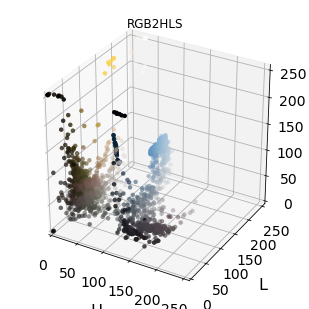

```python
plot3d(convert_color(img_small, color_spaces[4]), img_small_rgb, axis_labels=list("HLS"))
plt.title(color_spaces[4])
plt.show()
```

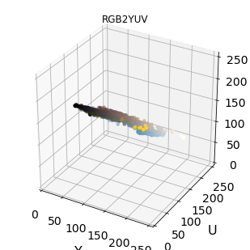

```python
plot3d(convert_color(img_small, color_spaces[5]), img_small_rgb, axis_labels=list("YUV"))
plt.title(color_spaces[5])
plt.show()
```

### Histograms of Color

In this section, the follwing parameters were tuned for histograms of color:

- color space
- number of histogram bins

```python
def get_histograms(image, color_spaces, bins=32):
    """Extracts histogram of colors features from an image."""
    histograms = []

    for space in color_spaces:
        img = convert_color(np.copy(image), space)

        # Compute the histogram of the RGB channels separately
        ch1_hist = np.histogram(img[:,:,0], bins=bins)
        ch2_hist = np.histogram(img[:,:,1], bins=bins)
        ch3_hist = np.histogram(img[:,:,2], bins=bins)

        # Generating bin centers
        bin_edges = ch1_hist[1]
        bin_centers = (bin_edges[1:]  + bin_edges[0:len(bin_edges)-1])/2

        # Concatenate the histograms into a single feature vector
        hist_features = np.concatenate((ch1_hist[0], ch2_hist[0], ch3_hist[0]))

        # Return the individual histograms, bin_centers and feature vector
        histogram = ch1_hist, ch2_hist, ch3_hist, bin_centers, hist_features
        histograms.append(histogram)

    return histograms

test_histograms = get_histograms(test_images[4], color_spaces, 8)
```

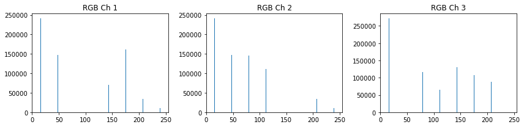

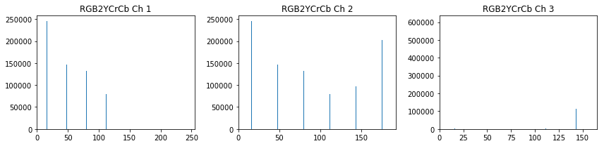

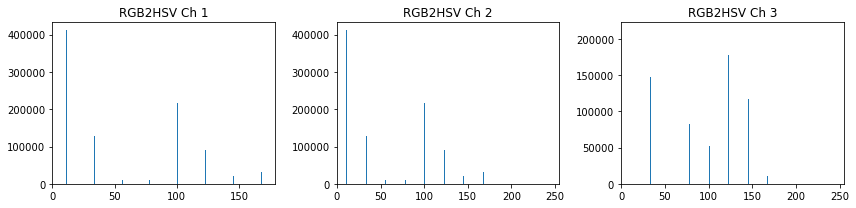

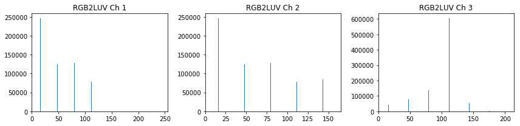

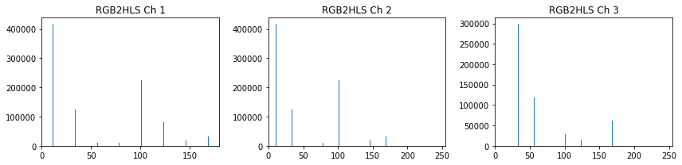

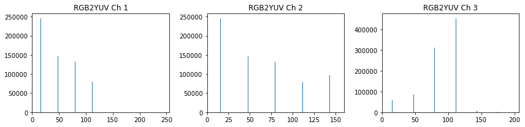

```python
def plot_histograms(plots):
    """Plots extracted histogram features in various color spaces."""
    for index, plot in enumerate(plots):
        ch1, ch2, ch3, bincen, feature_vec = plot

        fig = plt.figure(figsize=(12,3))

        space = color_spaces[index]

        plt.subplot(131)
        plt.bar(bincen, ch1[0])
        plt.xlim(0, max(ch1[1]))
        plt.title(space + ' Ch 1')

        plt.subplot(132)
        plt.bar(bincen, ch1[0])
        plt.xlim(0, max(ch2[1]))
        plt.title(space + ' Ch 2')

        plt.subplot(133)
        plt.bar(bincen, ch3[0])
        plt.xlim(0, max(ch3[1]))
        plt.title(space + ' Ch 3')

        fig.tight_layout()
    plt.show()

plot_histograms(test_histograms)
```

### Spatial Binning

In this section, the follwing parameters were tuned for spatial binning:

- color space
- spatial size

```python
def bin_spatial(image, color_spaces, size=(32, 32)):
    """Extracts spatial features from an image."""
    spatials = []

    for space in color_spaces:
        img = convert_color(np.copy(image), space)

        # Use cv2.resize().ravel() to create the feature vector
        resized = cv2.resize(img, size)
        spatial_features = resized.ravel()
        spatials.append(spatial_features)
    # Return the feature vector
    return spatials

spatial_feature_vecs = bin_spatial(test_images[4], color_spaces, size=(16, 16))
```

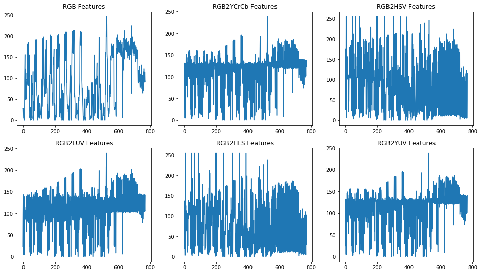

```python
def plot_spatial_bins(vectors):
    """Plots extracted spatial features in various color spaces."""
    fig = plt.figure(figsize=(16,9))

    columns = 3
    rows = round(len(vectors)/columns)

    for index, feature_vec in enumerate(vectors):
        a = fig.add_subplot(rows,columns,index+1)
        plt.title(color_spaces[index] + ' Features')
        plt.plot(feature_vec)
    plt.show()

plot_spatial_bins(spatial_feature_vecs)
```

### HOG Features

**Requirement: Explain how (and identify where in your code) you extracted HOG features from the training images.**

**Requirement: Explain how you settled on your final choice of HOG parameters.**

In this section, the follwing parameters were tuned for histograms of gradients:

- color space
- orientations
- pixels per cell
- cells per block

```python
# Define a function to return HOG features and visualization
def hog_features(img, orient, pix_per_cell, cell_per_block, vis=False, feature_vec=True):
    """Extracts HOG features from an image; takes a single channel input image."""
    if vis == True:
        features, hog_image = hog(img, orientations=orient, pixels_per_cell=(pix_per_cell, pix_per_cell),
                                  cells_per_block=(cell_per_block, cell_per_block), transform_sqrt=False,
                                  visualise=True, feature_vector=False)
        return features, hog_image
    else:
        features = hog(img, orientations=orient, pixels_per_cell=(pix_per_cell, pix_per_cell),
                       cells_per_block=(cell_per_block, cell_per_block), transform_sqrt=False,
                       visualise=False, feature_vector=feature_vec)
        return features

# Define HOG parameters
TEST_ORIENT = 6
TEST_PIX_PER_CELL = 8
TEST_CELL_PER_BLOCK = 2

# Read in the image
test_hog_img = mpimg.imread('hog_test_2.png')

# Call our function with vis=True to see an image output
def test_hogs(image):
    "Extracts HOG features from an image; takes in a 3-channel image and extracts features for each channel."
    hog_imgs = []

    for space in color_spaces:
        img = convert_color(np.copy(image), space)
        features, hog_image1 = hog_features(img[:,:,0],
                                               TEST_ORIENT, TEST_PIX_PER_CELL, TEST_CELL_PER_BLOCK,
                                               vis=True, feature_vec=False)
        features, hog_image2 = hog_features(img[:,:,1],
                                               TEST_ORIENT, TEST_PIX_PER_CELL, TEST_CELL_PER_BLOCK,
                                               vis=True, feature_vec=False)
        features, hog_image3 = hog_features(img[:,:,2],
                                               TEST_ORIENT, TEST_PIX_PER_CELL, TEST_CELL_PER_BLOCK,
                                               vis=True, feature_vec=False)

        hog_imgs.append(hog_image1); hog_imgs.append(hog_image2); hog_imgs.append(hog_image3);

    return hog_imgs

hog_images = test_hogs(test_hog_img)
```

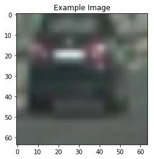

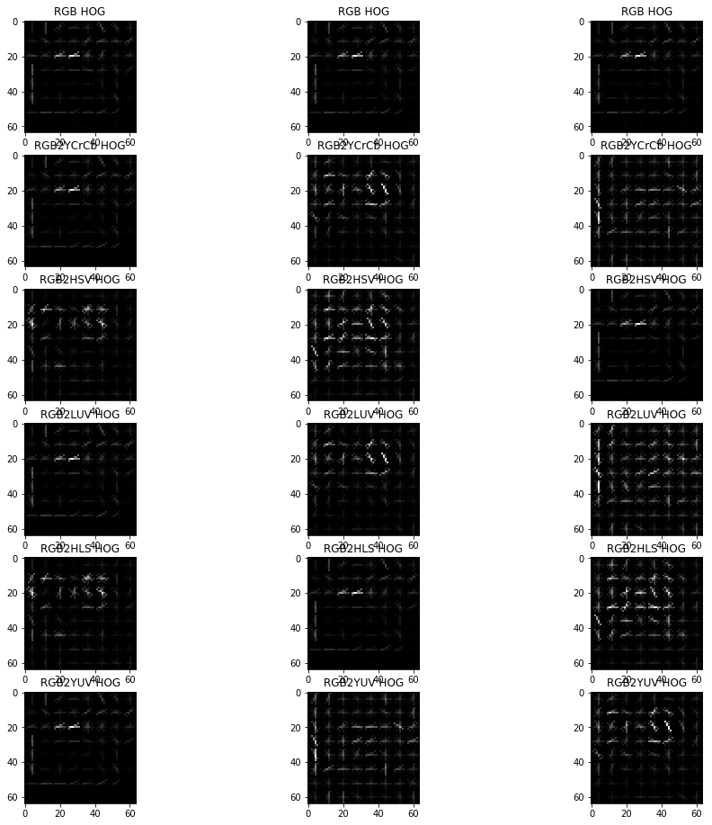

```python
def plot_hog_features(hogs):
    """Plots HOG features in various color spaces."""
    plt.imshow(test_hog_img)
    plt.title('Example Image')
    plt.show()

    fig = plt.figure(figsize=(16,16))

    columns = 3
    rows = round(len(hogs)/columns)

    for index, hog_img in enumerate(hogs):
        a = fig.add_subplot(rows,columns,index+1)
        plt.title(color_spaces[index//3] + ' HOG')
        plt.imshow(hog_img, cmap='gray')
    plt.show()

plot_hog_features(hog_images)
```

### Conclusion

Varying parameters had the following effects in tuning:

- increasing orientations resulted in higher quality features but increased processing time.
- decreasing pixels per cell resulted in higher quality features but increased processing time.
- decreasing cells per block resulted in higher quality features but increased processing time.
- HLS and HSV color spaces produced the most consitent results under varying lighting conditions and quality of images.

With these considerations in mind, orientation values of 6, pixels per cell values of 8 and cells per block values of 2 in HLS color space were good enough to produce acceptable HOG features.

Since classification will need to be performed in near-real-time, the increased processing time was too big of a penalty to accept.

As will be highlighted in the section on classification, when combined with spatial and color features, the feature set is robust enough to accurately detect cars.

### Import Data Set

Car and Non-car data is imported and a general assessment of the data is provided.

```
Cars: 8792
Not Cars: 8968
Total images:17760
Image shape: (64, 64, 3)
Data type: <class 'numpy.ndarray'>
```

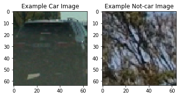

```python
# Import Car and Non-car data

cars = glob.glob('datasets/vehicles/**/*.png', recursive=True)
notcars = glob.glob('datasets/non-vehicles/**/*.png', recursive=True)

example = mpimg.imread(cars[0])

print('Cars: ' + str(len(cars)))
print('Not Cars: ' + str(len(notcars)))
print('Total images:' + str(len(cars) + len(notcars)))
print('Image shape: ' + str(example.shape))
print('Data type: ' + str(type(example)))

# Just for fun choose random car / not-car indices and plot example images
car_ind = np.random.randint(0, len(cars))
notcar_ind = np.random.randint(0, len(notcars))

# Read in car / not-car images
car_image = mpimg.imread(cars[car_ind])
notcar_image = mpimg.imread(notcars[notcar_ind])

# Plot the examples
fig = plt.figure()

plt.subplot(121)
plt.imshow(car_image)
plt.title('Example Car Image')

plt.subplot(122)
plt.imshow(notcar_image)
plt.title('Example Not-car Image')

plt.show()
```

# Vehicle Detection & Tracking

The final paramaters decided on are declared below. These paramters were chosen provide a balance between performance and accuracy.

```python
COLOR_CSPACE = 'RGB2LUV'
HOG_CSPACE = 'RGB2HLS'
FINAL_ORIENT = 6
FINAL_PIX_PER_CELL = 8
FINAL_CELL_PER_BLOCK = 2
FINAL_SPATIAL_SIZE = (16, 16)
FINAL_HIST_BINS = 8

ystart = 400
ystop = 656
SM_SCALE = 1.0
MED_SCALE = 2.0
LG_SCALE = 3.0
```

The following functions extract hog features, spatial features and histogram of color features respectively.

```python
def get_hog_features(img, orient, pix_per_cell, cell_per_block, vis=False, feature_vec=True):
    if vis == True:
        features, hog_image = hog(img, orientations=orient,
                                  pixels_per_cell=(pix_per_cell, pix_per_cell),
                                  cells_per_block=(cell_per_block, cell_per_block),
                                  transform_sqrt=False,
                                  visualise=vis, feature_vector=feature_vec)
        return features, hog_image
    else:
        features = hog(img, orientations=orient,
                       pixels_per_cell=(pix_per_cell, pix_per_cell),
                       cells_per_block=(cell_per_block, cell_per_block),
                       transform_sqrt=False,
                       visualise=vis, feature_vector=feature_vec)
        return features

def find_bin_spatial(img, size=(32, 32)):
    color1 = cv2.resize(img[:,:,0], size).ravel()
    color2 = cv2.resize(img[:,:,1], size).ravel()
    color3 = cv2.resize(img[:,:,2], size).ravel()
    return np.hstack((color1, color2, color3))

def find_color_hist(img, nbins=32):
    # Compute the histogram of the color channels separately
    channel1_hist = np.histogram(img[:,:,0], bins=nbins)
    channel2_hist = np.histogram(img[:,:,1], bins=nbins)
    channel3_hist = np.histogram(img[:,:,2], bins=nbins)

    # Concatenate the histograms into a single feature vector
    hist_features = np.concatenate((channel1_hist[0], channel2_hist[0], channel3_hist[0]))

    # Return the individual histograms, bin_centers and feature vector
    return hist_features
```

The following functions extract features from the entire dataset and individual image respectively.

```python
def get_features(files):
    """Extracts color, spatial and HOG features for a list of images."""
    combo = []
    for file in files:
        img = mpimg.imread(file)
        combo.append(extract_combined_features(img, COLOR_CSPACE, HOG_CSPACE))
    return combo

def extract_combined_features(img, color_cspace, hog_cspace):
    """Extracts color, spatial and HOG features for a single image."""
    # Apply color conversion if other than 'RGB'
    color_feature_image = convert_color(img, color_cspace)
    hog_feature_image = convert_color(img, hog_cspace)

    # Apply bin_spatial() to get spatial color features
    spatial_features = find_bin_spatial(color_feature_image, size=FINAL_SPATIAL_SIZE)

    # Apply color_hist() also with a color space option now
    hist_features = find_color_hist(color_feature_image, nbins=FINAL_HIST_BINS)

    # Append the new feature vector to the features list

    hog_feat1 = get_hog_features(hog_feature_image[:,:,0], FINAL_ORIENT, FINAL_PIX_PER_CELL, FINAL_CELL_PER_BLOCK)
    hog_feat2 = get_hog_features(hog_feature_image[:,:,1], FINAL_ORIENT, FINAL_PIX_PER_CELL, FINAL_CELL_PER_BLOCK)
    hog_feat3 = get_hog_features(hog_feature_image[:,:,2], FINAL_ORIENT, FINAL_PIX_PER_CELL, FINAL_CELL_PER_BLOCK)
    hogs_feats = np.hstack((hog_feat1, hog_feat2, hog_feat3))

    return np.hstack((spatial_features, hist_features, hogs_feats))
```

### Train Detection Classifier

**Requirement: Describe how (and identify where in your code) you trained a classifier using your selected HOG features (and color features if you used them).**

This section extracts features from the car and noncar datasets to train a Linear SVM model. Care was taken to normalize the combined features prior to training.

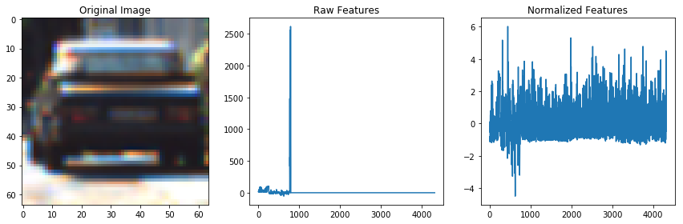

```
Using spatial binning of: (16, 16) and 8 histogram bins
Feature vector length: 4320
11.72 Seconds to train SVC...
Test Accuracy of SVC =  0.991
My SVC predicts:  [ 1.  1.  0.  0.  0.  0.  0.  1.  0.  0.  0.  1.  1.  0.  0.  0.  0.  0.
  1.  1.]
For these 20 labels:  [ 1.  1.  0.  0.  0.  0.  0.  1.  0.  0.  0.  1.  1.  0.  0.  0.  0.  0.
  1.  1.]
0.00235 Seconds to predict 20 labels with SVC
```

```python
car_feats = get_features(cars)
noncar_feats = get_features(notcars)

# Create an array stack of feature vectors
X = np.concatenate((car_feats, noncar_feats)).astype(np.float64)

# Fit a per-column scaler
X_scaler = StandardScaler().fit(X)

# Apply the scaler to X
scaled_X = X_scaler.transform(X)

car_ind = np.random.randint(0, len(cars))

# Plot an example of raw and scaled features
fig = plt.figure(figsize=(12,4))

plt.subplot(131)
plt.imshow(mpimg.imread(cars[car_ind]))
plt.title('Original Image')

plt.subplot(132)
plt.plot(X[car_ind])
plt.title('Raw Features')

plt.subplot(133)
plt.plot(scaled_X[car_ind])
plt.title('Normalized Features')

fig.tight_layout()
plt.show()


# Define the labels vector
y = np.hstack((np.ones(len(car_feats)), np.zeros(len(noncar_feats))))

# Split up data into randomized training and test sets
rand_state = np.random.randint(0, 100)
X_train, X_test, y_train, y_test = train_test_split(scaled_X, y, test_size=0.2, random_state=rand_state)

print('Using spatial binning of:',FINAL_SPATIAL_SIZE,'and', FINAL_HIST_BINS,'histogram bins')
print('Feature vector length:', len(X_train[0]))

# Use a linear SVC
svc = svm.LinearSVC()

# Check the training time for the SVC
t=time.time()
svc.fit(X_train, y_train)
t2 = time.time()
print(round(t2-t, 2), 'Seconds to train SVC...')

# Check the score of the SVC
print('Test Accuracy of SVC = ', round(svc.score(X_test, y_test), 4))

# Check the prediction time for a single sample
t=time.time()
n_predict = 20
print('My SVC predicts: ', svc.predict(X_test[0:n_predict]))
print('For these',n_predict, 'labels: ', y_test[0:n_predict])
t2 = time.time()
print(round(t2-t, 5), 'Seconds to predict', n_predict,'labels with SVC')
```

### Find Cars

**Requirement: Describe how (and identify where in your code) you implemented a sliding window search. How did you decide what scales to search and how much to overlap windows?**

The `find_cars()` function detects HOG features over the entire region of interest in an input image then subsamples portions of the image to extract HOG features, spatial features and color features over a scaled window.

I decided to use three subsample sizes at 1x, 2x and 3x equating to 64px, 128px, and 192px respectively.

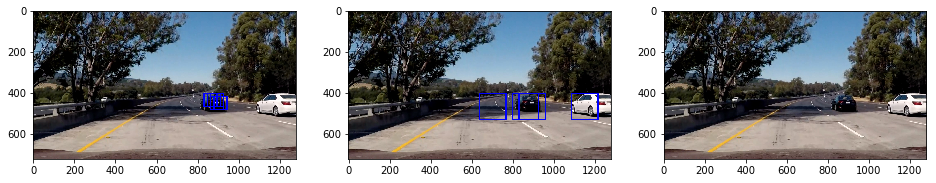

```python
def find_cars(img, ystart, ystop, scale, svc, X_scaler, orient, pix_per_cell, cell_per_block, spatial_size, hist_bins):
    """ Extract features using HOG sub-sampling and make predictions."""

    # Preserve full image to draw rectangles over
    draw_img = np.copy(img)

    """
    Set image value range of 0 to 1 to match those of images used while training the model.
    Data set images are PNG vs. test images/video frames which are JPEG
    """
    img = img.astype(np.float32)/255

    # Set vehicle detection region of interest
    img_tosearch = img[ystart:ystop,:,:]

    # Convert image to desired color space
    ctrans_tosearch = convert_color(img_tosearch, HOG_CSPACE)
    color_trans = convert_color(img_tosearch, COLOR_CSPACE)

    if scale != 1:
        imshape = ctrans_tosearch.shape
        ctrans_tosearch = cv2.resize(ctrans_tosearch, (np.int(imshape[1]/scale), np.int(imshape[0]/scale)))

    # HOG Color channels
    ch1 = ctrans_tosearch[:,:,0]
    ch2 = ctrans_tosearch[:,:,1]
    ch3 = ctrans_tosearch[:,:,2]

    # Define blocks and steps as above
    nxblocks = (ch1.shape[1] // pix_per_cell) - cell_per_block + 1
    nyblocks = (ch1.shape[0] // pix_per_cell) - cell_per_block + 1
    nfeat_per_block = orient*cell_per_block**2

    # 64 was the orginal sampling rate, with 8 cells and 8 pix per cell
    window = 64
    nblocks_per_window = (window // pix_per_cell) - cell_per_block + 1
    cells_per_step = 2  # Instead of overlap, define how many cells to step
    nxsteps = (nxblocks - nblocks_per_window) // cells_per_step
    nysteps = (nyblocks - nblocks_per_window) // cells_per_step

    # Compute individual channel HOG features for the entire image
    hog1 = get_hog_features(ch1, orient, pix_per_cell, cell_per_block, feature_vec=False)
    hog2 = get_hog_features(ch2, orient, pix_per_cell, cell_per_block, feature_vec=False)
    hog3 = get_hog_features(ch3, orient, pix_per_cell, cell_per_block, feature_vec=False)

    # A list to store all the windows where vehicles are detected
    car_windows = []

    for xb in range(nxsteps):
        for yb in range(nysteps):
            ypos = yb*cells_per_step
            xpos = xb*cells_per_step

            # Extract HOG for this patch
            hog_feat1 = hog1[ypos:ypos+nblocks_per_window, xpos:xpos+nblocks_per_window].ravel()
            hog_feat2 = hog2[ypos:ypos+nblocks_per_window, xpos:xpos+nblocks_per_window].ravel()
            hog_feat3 = hog3[ypos:ypos+nblocks_per_window, xpos:xpos+nblocks_per_window].ravel()
            hog_features = np.hstack((hog_feat1, hog_feat2, hog_feat3))

            xleft = xpos*pix_per_cell
            ytop = ypos*pix_per_cell

            # Extract the image patch
            subimg = cv2.resize(color_trans[ytop:ytop+window, xleft:xleft+window], (64,64))

            # Get color features
            spatial_features = find_bin_spatial(subimg, size=spatial_size)
            hist_features = find_color_hist(subimg, nbins=hist_bins)

            # Scale features and make a prediction
            test_features = X_scaler.transform(np.hstack((spatial_features, hist_features, hog_features)).reshape(1, -1))

            test_prediction = svc.predict(test_features)

            if test_prediction == 1:
                xbox_left = np.int(xleft*scale)
                ytop_draw = np.int(ytop*scale)
                win_draw = np.int(window*scale)
                cv2.rectangle(draw_img,(xbox_left, ytop_draw+ystart),(xbox_left+win_draw,ytop_draw+win_draw+ystart),(0,0,255),6)

                car_windows.append(((xbox_left, ytop_draw+ystart),(xbox_left+win_draw,ytop_draw+win_draw+ystart)))
    return draw_img, car_windows

track_example = np.copy(test_images[4])

scale1_img, scale1_windows = find_cars(track_example, ystart, ystop, SM_SCALE, svc, X_scaler, FINAL_ORIENT, FINAL_PIX_PER_CELL, FINAL_CELL_PER_BLOCK, FINAL_SPATIAL_SIZE, FINAL_HIST_BINS)
scale2_img, scale2_windows = find_cars(track_example, ystart, ystop, MED_SCALE, svc, X_scaler, FINAL_ORIENT, FINAL_PIX_PER_CELL, FINAL_CELL_PER_BLOCK, FINAL_SPATIAL_SIZE, FINAL_HIST_BINS)
scale3_img, scale3_windows = find_cars(track_example, ystart, ystop, LG_SCALE, svc, X_scaler, FINAL_ORIENT, FINAL_PIX_PER_CELL, FINAL_CELL_PER_BLOCK, FINAL_SPATIAL_SIZE, FINAL_HIST_BINS)

plot_grid([scale1_img, scale2_img, scale3_img])
```

### Multiple Detections & False Positives

**Requirement: Describe how (and identify where in your code) you implemented some kind of filter for false positives and some method for combining overlapping bounding boxes.**

To detect and resolve multiple detections and false positives, a heatmap is applied, such that overlapping boxes are conjoined and a threshold is applied to enforce displaying high-confidence detections.

**Note:** the test images, use a lower detection (1) threshold, whereas the processed images from the video will have a higher threshold (3), since the heatmap will be more intense as detections are tracked over a number of frames.

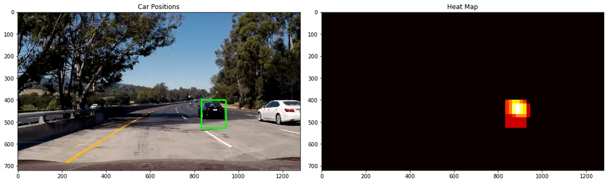

```python
DETECTION_THRESHOLD = 3

# Get all boxes detected by sliding windows search
box_list = scale1_windows + scale2_windows + scale3_windows

# Read in image similar to one shown above
multi_detection_image = np.copy(test_images[4])

heat = np.zeros_like(multi_detection_image[:,:,0]).astype(np.float)

def add_heat(heatmap, bbox_list):
    # Iterate through list of bboxes
    for box in bbox_list:
        # Add += 1 for all pixels inside each bbox
        heatmap[box[0][1]:box[1][1], box[0][0]:box[1][0]] += 1

    # Return updated heatmap
    return heatmap# Iterate through list of bboxes

def apply_threshold(heatmap, threshold=DETECTION_THRESHOLD):
    # Zero out pixels below the threshold
    heatmap[heatmap <= threshold] = 0

    # Return thresholded map
    return heatmap

def draw_labeled_bboxes(img, labels):
    # Iterate through all detected cars
    for car_number in range(1, labels[1]+1):
        # Find pixels with each car_number label value
        nonzero = (labels[0] == car_number).nonzero()

        # Identify x and y values of those pixels
        nonzeroy = np.array(nonzero[0])
        nonzerox = np.array(nonzero[1])

        # Define a bounding box based on min/max x and y
        bbox = ((np.min(nonzerox), np.min(nonzeroy)), (np.max(nonzerox), np.max(nonzeroy)))

        # Draw the box on the image
        cv2.rectangle(img, bbox[0], bbox[1], (0,255,0), 6)
    # Return the image
    return img

# Add heat to each box in box list
heat = add_heat(heat,box_list)

# Apply threshold to help remove false positives
heat = apply_threshold(heat,1)

# Visualize the heatmap when displaying
heatmap = np.clip(heat, 0, 255)

# Find final boxes from heatmap using label function
labels = label(heatmap)

draw_img = draw_labeled_bboxes(np.copy(multi_detection_image), labels)

fig = plt.figure(figsize=(16,9))
plt.subplot(121)
plt.imshow(draw_img)
plt.title('Car Positions')
plt.subplot(122)
plt.imshow(heatmap, cmap='hot')
plt.title('Heat Map')
fig.tight_layout()

plt.show()
```

### Process Frame

This section defines two functions; one for removing multiple and false detections, and the other for returning all bounding boxes around areas where a car has been detected.

```python
BUFFER_RATE = 10

def highlight_cars(image, windows, threshold):

    hot = np.zeros_like(image[:,:,0]).astype(np.float)

    # Add heat to each box in box list
    hot = add_heat(hot, windows)

    # Apply threshold to help remove false positives
    hot = apply_threshold(hot, threshold)

    # Visualize the heatmap when displaying
    heat_map = np.clip(hot, 0, 255)

    # Find final boxes from heatmap using label function
    heat_labels = label(heat_map)
    highlight_image = draw_labeled_bboxes(np.copy(image), heat_labels)
    return highlight_image

def get_windows(img):
    sm_img, sm_windows = find_cars(img, ystart, ystop, SM_SCALE, svc, X_scaler, FINAL_ORIENT, FINAL_PIX_PER_CELL, FINAL_CELL_PER_BLOCK, FINAL_SPATIAL_SIZE, FINAL_HIST_BINS)
    med_img, med_windows = find_cars(img, ystart, ystop, MED_SCALE, svc, X_scaler, FINAL_ORIENT, FINAL_PIX_PER_CELL, FINAL_CELL_PER_BLOCK, FINAL_SPATIAL_SIZE, FINAL_HIST_BINS)
    lg_img, lg_windows = find_cars(img, ystart, ystop, LG_SCALE, svc, X_scaler, FINAL_ORIENT, FINAL_PIX_PER_CELL, FINAL_CELL_PER_BLOCK, FINAL_SPATIAL_SIZE, FINAL_HIST_BINS)

    windows = sm_windows + med_windows + lg_windows

    return windows

def process_frame(frame, buffer=None):

    all_windows = []

    # If there is no current buffer, create it
    if buffer is None:
        buffer = []
        buffer.append(frame)
    # If buffer is non-empty but less than buffer threshold, add current frame
    elif len(buffer) < BUFFER_RATE and len(buffer) > 0:
        for img in buffer:
            all_windows += get_windows(img)
        buffer.append(frame)
    # If buffer is non-empty but equal to or greater than threshold, remove oldest frame, then add current
    elif len(buffer) >= BUFFER_RATE and len(buffer) > 0:
        del(buffer[0])
        for img in buffer:
            all_windows += get_windows(img)
        buffer.append(frame)

    # Extract windows from current frame
    all_windows += get_windows(frame)

    return highlight_cars(frame, all_windows, DETECTION_THRESHOLD), buffer
```

**Requirement: Show some examples of test images to demonstrate how your pipeline is working. What did you do to optimize the performance of your classifier?**

A test image depicting where some false positives have been detected.

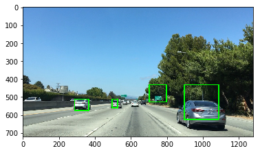

```python
bbox_img = cv2.imread('bbox-example-image.jpg')
bbox_img = cv2.cvtColor(bbox_img, cv2.COLOR_BGR2RGB)

bbox_result, bbox_buffer = process_frame(bbox_img)
plt.imshow(bbox_result)
plt.show()
```

Using the test image set provided to show car detection. No false positives are shown in these examples.

```
Frame processed in: 1.76 seconds
Frame processed in: 1.747 seconds
Frame processed in: 1.77 seconds
Frame processed in: 1.765 seconds
Frame processed in: 1.926 seconds
Frame processed in: 1.816 seconds
```

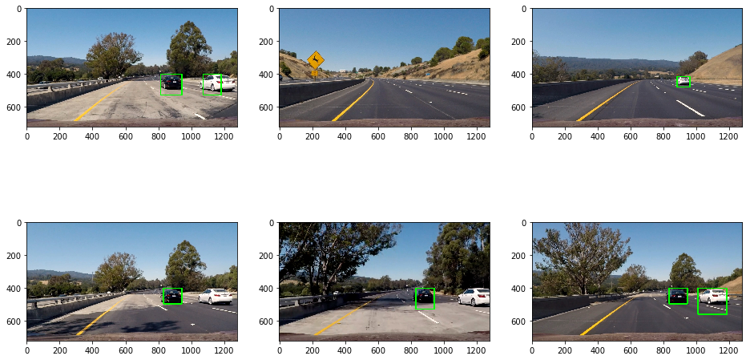

```python
def scan_test_images(images):

    scans = []

    for img in images:
        start = time.time()
        windows = get_windows(img)

        scans.append(highlight_cars(img, windows, threshold=1))

        end = time.time()

        print('Frame processed in:', round(end - start, 3), 'seconds')
    return scans

plot_grid(scan_test_images(test_images))
```

## Video Implementation

**Requirement: Provide a link to your final video output. Your pipeline should perform reasonably well on the entire project video (somewhat wobbly or unstable bounding boxes are ok as long as you are identifying the vehicles most of the time with minimal false positives.)**

### Process Video

```python
def process_video(input_path, output_path):
    clip  = VideoFileClip(input_path)

    print("Processing video...")
    print("Clip fps:", clip.fps, "Approx frames:", clip.fps * 50)

    start = time.time()
    count = 0

    new_frames = []

    buffer = None

    for frame in clip.iter_frames():
        out_img, prev_frames = process_frame(frame, buffer)

        new_frames.append(out_img)
        buffer = prev_frames

        count = count + 1
        print("Clip:", count)

    new_clip = ImageSequenceClip(new_frames, fps=clip.fps)
    new_clip.write_videofile(output_path, audio=False)

    end = time.time()

    print('Video processing time:', round((end-start)/60, 3), 'minutes')
    HTML("""
    <video width="1280" height="720" controls>
      <source src="{0}">
    </video>
    """.format(output_path))
```

### Test Video

```python
test_input = "test_video.mp4"
test_output = "output_images/video_test.mp4"

process_video(test_input, test_output)
```

### Project Video

```python
project_input = "project_video.mp4"
project_output = "output_images/video_project.mp4"

process_video(project_input, project_output)
```

## Discussion

**Requirement: Briefly discuss any problems / issues you faced in your implementation of this project. Where will your pipeline likely fail? What could you do to make it more robust?**

**Challenges Faced**

- Feature extraction & parameter tuning: figuring out the "right" combination of features and parameters is a lengthy process.
- Performance limitations: more features can lead to more accuracte detections but require more processing time and require more time to train a detection model.
- While tracking cars over frames improved the confidence of detections, it introduced more false positives than initially.

**Where is pipeline likely to fail?**

- In areas with dark shadows or sharp gradients.

**What could make it more robust?**

- Training the model on additional data.
- Using a decision tree to figure which features contribute more to accuracte vehicle detection.
- Using a neural network to assist with detection.
- Improvemets can be made to tracking cars over several frames, and better rejection of false positives.